# Risk Factor Analysis

## Outcome Variable

**Outcome Variable:** pers_wast

## Predictor Variables

**Intervention Variable:** feducyrs

**Adjustment Set:**

unadjusted

## Stratifying Variables

The analysis was stratified on these variable(s):

- agecat
- studyid
- country

## Data Summary

| agecat | studyid | country | feducyrs | pers_wast | n_cell | n |
| --- | --- | --- | --- | --- | --- | --- |
| 0-24 months | ki0047075b-MAL-ED | BANGLADESH | Low | 0 | 38 | 138 |
| 0-24 months | ki0047075b-MAL-ED | BANGLADESH | Low | 1 | 0 | 138 |
| 0-24 months | ki0047075b-MAL-ED | BANGLADESH | Medium | 0 | 45 | 138 |
| 0-24 months | ki0047075b-MAL-ED | BANGLADESH | Medium | 1 | 4 | 138 |
| 0-24 months | ki0047075b-MAL-ED | BANGLADESH | High | 0 | 48 | 138 |
| 0-24 months | ki0047075b-MAL-ED | BANGLADESH | High | 1 | 3 | 138 |
| 0-24 months | ki0047075b-MAL-ED | INDIA | Low | 0 | 51 | 139 |
| 0-24 months | ki0047075b-MAL-ED | INDIA | Low | 1 | 4 | 139 |
| 0-24 months | ki0047075b-MAL-ED | INDIA | Medium | 0 | 32 | 139 |
| 0-24 months | ki0047075b-MAL-ED | INDIA | Medium | 1 | 9 | 139 |
| 0-24 months | ki0047075b-MAL-ED | INDIA | High | 0 | 43 | 139 |
| 0-24 months | ki0047075b-MAL-ED | INDIA | High | 1 | 0 | 139 |
| 0-24 months | ki0047075b-MAL-ED | NEPAL | Low | 0 | 27 | 96 |
| 0-24 months | ki0047075b-MAL-ED | NEPAL | Low | 1 | 0 | 96 |
| 0-24 months | ki0047075b-MAL-ED | NEPAL | Medium | 0 | 27 | 96 |
| 0-24 months | ki0047075b-MAL-ED | NEPAL | Medium | 1 | 1 | 96 |
| 0-24 months | ki0047075b-MAL-ED | NEPAL | High | 0 | 40 | 96 |
| 0-24 months | ki0047075b-MAL-ED | NEPAL | High | 1 | 1 | 96 |
| 0-24 months | ki0047075b-MAL-ED | PERU | Low | 0 | 63 | 234 |
| 0-24 months | ki0047075b-MAL-ED | PERU | Low | 1 | 0 | 234 |
| 0-24 months | ki0047075b-MAL-ED | PERU | Medium | 0 | 60 | 234 |
| 0-24 months | ki0047075b-MAL-ED | PERU | Medium | 1 | 0 | 234 |
| 0-24 months | ki0047075b-MAL-ED | PERU | High | 0 | 110 | 234 |
| 0-24 months | ki0047075b-MAL-ED | PERU | High | 1 | 1 | 234 |
| 0-24 months | ki0047075b-MAL-ED | SOUTH AFRICA | Low | 0 | 35 | 99 |
| 0-24 months | ki0047075b-MAL-ED | SOUTH AFRICA | Low | 1 | 1 | 99 |
| 0-24 months | ki0047075b-MAL-ED | SOUTH AFRICA | Medium | 0 | 25 | 99 |
| 0-24 months | ki0047075b-MAL-ED | SOUTH AFRICA | Medium | 1 | 0 | 99 |
| 0-24 months | ki0047075b-MAL-ED | SOUTH AFRICA | High | 0 | 38 | 99 |
| 0-24 months | ki0047075b-MAL-ED | SOUTH AFRICA | High | 1 | 0 | 99 |

[output cut: 252 more lines]

The following strata were considered:

- agecat: 0-24 months, studyid: ki0047075b-MAL-ED, country: BANGLADESH
- agecat: 0-24 months, studyid: ki0047075b-MAL-ED, country: INDIA
- agecat: 0-24 months, studyid: ki0047075b-MAL-ED, country: NEPAL
- agecat: 0-24 months, studyid: ki0047075b-MAL-ED, country: PERU
- agecat: 0-24 months, studyid: ki0047075b-MAL-ED, country: SOUTH AFRICA
- agecat: 0-24 months, studyid: ki0047075b-MAL-ED, country: TANZANIA, UNITED REPUBLIC OF
- agecat: 0-24 months, studyid: ki1000304b-SAS-CompFeed, country: INDIA
- agecat: 0-24 months, studyid: ki1000304b-SAS-FoodSuppl, country: INDIA
- agecat: 0-24 months, studyid: ki1017093b-PROVIDE, country: BANGLADESH
- agecat: 0-24 months, studyid: ki1017093c-NIH-Crypto, country: BANGLADESH
- agecat: 0-24 months, studyid: ki1066203-TanzaniaChild2, country: TANZANIA, UNITED REPUBLIC OF
- agecat: 0-24 months, studyid: ki1113344-GMS-Nepal, country: NEPAL
- agecat: 0-24 months, studyid: ki1119695-PROBIT, country: BELARUS
- agecat: 0-24 months, studyid: ki1126311-ZVITAMBO, country: ZIMBABWE
- agecat: 0-24 months, studyid: ki1135781-COHORTS, country: GUATEMALA
- agecat: 0-24 months, studyid: ki1135781-COHORTS, country: INDIA
- agecat: 0-24 months, studyid: ki1135781-COHORTS, country: PHILIPPINES
- agecat: 0-24 months, studyid: ki1148112-LCNI-5, country: MALAWI
- agecat: 0-24 months, studyid: kiGH5241-JiVitA-3, country: BANGLADESH
- agecat: 0-24 months, studyid: kiGH5241-JiVitA-4, country: BANGLADESH
- agecat: 0-6 months, studyid: ki0047075b-MAL-ED, country: BANGLADESH
- agecat: 0-6 months, studyid: ki0047075b-MAL-ED, country: INDIA
- agecat: 0-6 months, studyid: ki0047075b-MAL-ED, country: NEPAL
- agecat: 0-6 months, studyid: ki0047075b-MAL-ED, country: PERU
- agecat: 0-6 months, studyid: ki0047075b-MAL-ED, country: SOUTH AFRICA
- agecat: 0-6 months, studyid: ki0047075b-MAL-ED, country: TANZANIA, UNITED REPUBLIC OF
- agecat: 0-6 months, studyid: ki1017093b-PROVIDE, country: BANGLADESH
- agecat: 0-6 months, studyid: ki1066203-TanzaniaChild2, country: TANZANIA, UNITED REPUBLIC OF
- agecat: 0-6 months, studyid: ki1113344-GMS-Nepal, country: NEPAL
- agecat: 6-24 months, studyid: ki0047075b-MAL-ED, country: BANGLADESH
- agecat: 6-24 months, studyid: ki0047075b-MAL-ED, country: INDIA
- agecat: 6-24 months, studyid: ki0047075b-MAL-ED, country: NEPAL
- agecat: 6-24 months, studyid: ki0047075b-MAL-ED, country: PERU
- agecat: 6-24 months, studyid: ki0047075b-MAL-ED, country: SOUTH AFRICA
- agecat: 6-24 months, studyid: ki0047075b-MAL-ED, country: TANZANIA, UNITED REPUBLIC OF
- agecat: 6-24 months, studyid: ki1000304b-SAS-CompFeed, country: INDIA
- agecat: 6-24 months, studyid: ki1000304b-SAS-FoodSuppl, country: INDIA
- agecat: 6-24 months, studyid: ki1017093b-PROVIDE, country: BANGLADESH
- agecat: 6-24 months, studyid: ki1017093c-NIH-Crypto, country: BANGLADESH
- agecat: 6-24 months, studyid: ki1066203-TanzaniaChild2, country: TANZANIA, UNITED REPUBLIC OF
- agecat: 6-24 months, studyid: ki1113344-GMS-Nepal, country: NEPAL
- agecat: 6-24 months, studyid: ki1119695-PROBIT, country: BELARUS
- agecat: 6-24 months, studyid: ki1126311-ZVITAMBO, country: ZIMBABWE
- agecat: 6-24 months, studyid: ki1135781-COHORTS, country: GUATEMALA
- agecat: 6-24 months, studyid: ki1135781-COHORTS, country: PHILIPPINES
- agecat: 6-24 months, studyid: ki1148112-LCNI-5, country: MALAWI
- agecat: 6-24 months, studyid: kiGH5241-JiVitA-4, country: BANGLADESH

### Dropped Strata

Some strata were dropped due to rare outcomes:

- agecat: 0-24 months, studyid: ki0047075b-MAL-ED, country: BANGLADESH
- agecat: 0-24 months, studyid: ki0047075b-MAL-ED, country: INDIA
- agecat: 0-24 months, studyid: ki0047075b-MAL-ED, country: NEPAL
- agecat: 0-24 months, studyid: ki0047075b-MAL-ED, country: PERU
- agecat: 0-24 months, studyid: ki0047075b-MAL-ED, country: SOUTH AFRICA
- agecat: 0-24 months, studyid: ki0047075b-MAL-ED, country: TANZANIA, UNITED REPUBLIC OF
- agecat: 0-24 months, studyid: ki1017093b-PROVIDE, country: BANGLADESH
- agecat: 0-24 months, studyid: ki1017093c-NIH-Crypto, country: BANGLADESH
- agecat: 0-24 months, studyid: ki1148112-LCNI-5, country: MALAWI
- agecat: 0-6 months, studyid: ki0047075b-MAL-ED, country: BANGLADESH
- agecat: 0-6 months, studyid: ki0047075b-MAL-ED, country: INDIA
- agecat: 0-6 months, studyid: ki0047075b-MAL-ED, country: NEPAL
- agecat: 0-6 months, studyid: ki0047075b-MAL-ED, country: PERU
- agecat: 0-6 months, studyid: ki0047075b-MAL-ED, country: SOUTH AFRICA
- agecat: 0-6 months, studyid: ki0047075b-MAL-ED, country: TANZANIA, UNITED REPUBLIC OF
- agecat: 0-6 months, studyid: ki1017093b-PROVIDE, country: BANGLADESH
- agecat: 6-24 months, studyid: ki0047075b-MAL-ED, country: BANGLADESH
- agecat: 6-24 months, studyid: ki0047075b-MAL-ED, country: INDIA
- agecat: 6-24 months, studyid: ki0047075b-MAL-ED, country: NEPAL
- agecat: 6-24 months, studyid: ki0047075b-MAL-ED, country: PERU
- agecat: 6-24 months, studyid: ki0047075b-MAL-ED, country: SOUTH AFRICA
- agecat: 6-24 months, studyid: ki0047075b-MAL-ED, country: TANZANIA, UNITED REPUBLIC OF
- agecat: 6-24 months, studyid: ki1119695-PROBIT, country: BELARUS
- agecat: 6-24 months, studyid: ki1148112-LCNI-5, country: MALAWI

## Methods Detail

We’re interested in the causal parameters $E[Y_a]$ for all values of $a \in \mathcal{A}$. These parameters represent the mean outcome if, possibly contrary to fact, we intervened to set all units to have $A=a$. Under the randomization and positivity assumptions, these are identified by the statistical parameters $\psi_a=E_W[E_{Y|A,W}(Y|A=a,W)]$. In addition, we’re interested in the mean of $Y$, $E[Y]$ under no intervention (the observed mean). We will estimate these parameters by using SuperLearner to fit the relevant likelihood factors – $E_{Y|A,W}(Y|A=a,W)$ and $p(A=a|W)$, and then updating our likelihood fit using a joint TMLE.

For unadjusted analyses ($W=\{\}$), initial likelihoods were estimated using Lrnr_glm to estimate the simple $E(Y|A)$ and Lrnr_mean to estimate $p(A)$. For adjusted analyses, a small library containing Lrnr_glmnet, Lrnr_xgboost, and Lrnr_mean was used.

Having estimated these parameters, we will then use the delta method to estimate relative risks and attributable risks relative to a prespecified baseline level of $A$.

# Results Detail

## Results Plots

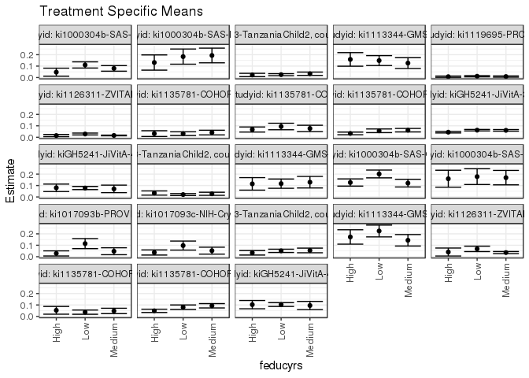

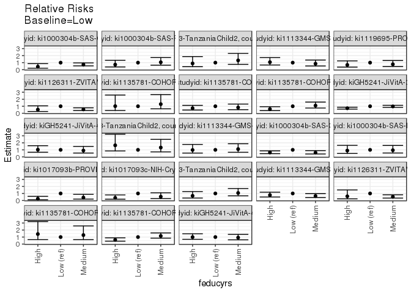

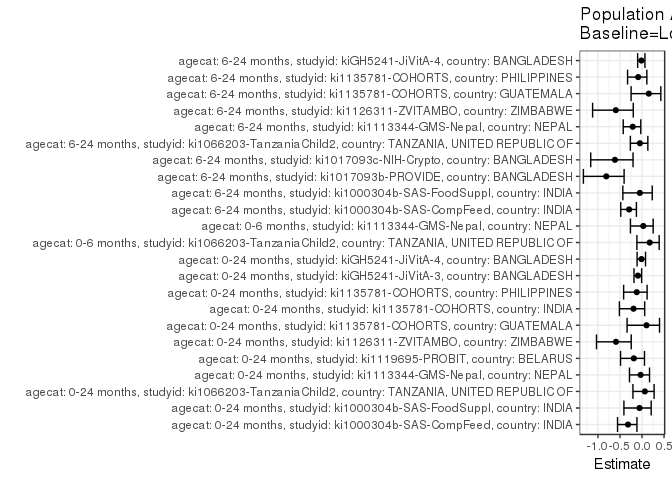

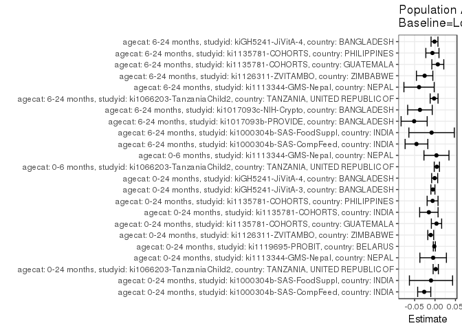

## Results Table

### Parameter: TSM

| agecat | studyid | country | intervention_level | baseline_level | estimate | ci_lower | ci_upper |
| --- | --- | --- | --- | --- | --- | --- | --- |
| 0-24 months | ki1000304b-SAS-CompFeed | INDIA | Low | NA | 0.1101243 | 0.0830059 | 0.1372428 |
| 0-24 months | ki1000304b-SAS-CompFeed | INDIA | Medium | NA | 0.0799087 | 0.0554976 | 0.1043198 |
| 0-24 months | ki1000304b-SAS-CompFeed | INDIA | High | NA | 0.0469613 | 0.0119037 | 0.0820190 |
| 0-24 months | ki1000304b-SAS-FoodSuppl | INDIA | Low | NA | 0.1832061 | 0.1168748 | 0.2495374 |
| 0-24 months | ki1000304b-SAS-FoodSuppl | INDIA | Medium | NA | 0.1931034 | 0.1287684 | 0.2574385 |
| 0-24 months | ki1000304b-SAS-FoodSuppl | INDIA | High | NA | 0.1313131 | 0.0646944 | 0.1979318 |
| 0-24 months | ki1066203-TanzaniaChild2 | TANZANIA, UNITED REPUBLIC OF | Low | NA | 0.0251736 | 0.0161255 | 0.0342217 |
| 0-24 months | ki1066203-TanzaniaChild2 | TANZANIA, UNITED REPUBLIC OF | Medium | NA | 0.0332779 | 0.0189349 | 0.0476209 |
| 0-24 months | ki1066203-TanzaniaChild2 | TANZANIA, UNITED REPUBLIC OF | High | NA | 0.0223881 | 0.0079228 | 0.0368534 |
| 0-24 months | ki1113344-GMS-Nepal | NEPAL | Low | NA | 0.1484375 | 0.1048486 | 0.1920264 |
| 0-24 months | ki1113344-GMS-Nepal | NEPAL | Medium | NA | 0.1263158 | 0.0790393 | 0.1735923 |
| 0-24 months | ki1113344-GMS-Nepal | NEPAL | High | NA | 0.1586207 | 0.0991083 | 0.2181331 |
| 0-24 months | ki1119695-PROBIT | BELARUS | Low | NA | 0.0112466 | 0.0060260 | 0.0164672 |
| 0-24 months | ki1119695-PROBIT | BELARUS | Medium | NA | 0.0086366 | 0.0034510 | 0.0138222 |
| 0-24 months | ki1119695-PROBIT | BELARUS | High | NA | 0.0075930 | 0.0020886 | 0.0130974 |
| 0-24 months | ki1126311-ZVITAMBO | ZIMBABWE | Low | NA | 0.0284450 | 0.0202527 | 0.0366373 |
| 0-24 months | ki1126311-ZVITAMBO | ZIMBABWE | Medium | NA | 0.0157297 | 0.0127864 | 0.0186730 |
| 0-24 months | ki1126311-ZVITAMBO | ZIMBABWE | High | NA | 0.0148026 | 0.0052031 | 0.0244022 |
| 0-24 months | ki1135781-COHORTS | GUATEMALA | Low | NA | 0.0314607 | 0.0152340 | 0.0476873 |
| 0-24 months | ki1135781-COHORTS | GUATEMALA | Medium | NA | 0.0409836 | 0.0206627 | 0.0613045 |
| 0-24 months | ki1135781-COHORTS | GUATEMALA | High | NA | 0.0319149 | 0.0067764 | 0.0570534 |
| 0-24 months | ki1135781-COHORTS | INDIA | Low | NA | 0.0940594 | 0.0655831 | 0.1225357 |
| 0-24 months | ki1135781-COHORTS | INDIA | Medium | NA | 0.0769231 | 0.0490351 | 0.1048110 |
| 0-24 months | ki1135781-COHORTS | INDIA | High | NA | 0.0677618 | 0.0454305 | 0.0900931 |
| 0-24 months | ki1135781-COHORTS | PHILIPPINES | Low | NA | 0.0564103 | 0.0402163 | 0.0726042 |
| 0-24 months | ki1135781-COHORTS | PHILIPPINES | Medium | NA | 0.0617155 | 0.0464586 | 0.0769723 |
| 0-24 months | ki1135781-COHORTS | PHILIPPINES | High | NA | 0.0335861 | 0.0219612 | 0.0452111 |
| 0-24 months | kiGH5241-JiVitA-3 | BANGLADESH | Low | NA | 0.0619289 | 0.0553765 | 0.0684814 |
| 0-24 months | kiGH5241-JiVitA-3 | BANGLADESH | Medium | NA | 0.0603365 | 0.0532666 | 0.0674064 |
| 0-24 months | kiGH5241-JiVitA-3 | BANGLADESH | High | NA | 0.0443609 | 0.0374017 | 0.0513201 |
| 0-24 months | kiGH5241-JiVitA-4 | BANGLADESH | Low | NA | 0.0782689 | 0.0643527 | 0.0921851 |
| 0-24 months | kiGH5241-JiVitA-4 | BANGLADESH | Medium | NA | 0.0706150 | 0.0377901 | 0.1034400 |
| 0-24 months | kiGH5241-JiVitA-4 | BANGLADESH | High | NA | 0.0802139 | 0.0475468 | 0.1128810 |
| 0-6 months | ki1066203-TanzaniaChild2 | TANZANIA, UNITED REPUBLIC OF | Low | NA | 0.0209281 | 0.0124631 | 0.0293931 |
| 0-6 months | ki1066203-TanzaniaChild2 | TANZANIA, UNITED REPUBLIC OF | Medium | NA | 0.0278261 | 0.0143793 | 0.0412729 |
| 0-6 months | ki1066203-TanzaniaChild2 | TANZANIA, UNITED REPUBLIC OF | High | NA | 0.0344828 | 0.0160596 | 0.0529059 |
| 0-6 months | ki1113344-GMS-Nepal | NEPAL | Low | NA | 0.1166667 | 0.0760149 | 0.1573185 |
| 0-6 months | ki1113344-GMS-Nepal | NEPAL | Medium | NA | 0.1294118 | 0.0789086 | 0.1799149 |
| 0-6 months | ki1113344-GMS-Nepal | NEPAL | High | NA | 0.1145038 | 0.0599258 | 0.1690818 |
| 6-24 months | ki1000304b-SAS-CompFeed | INDIA | Low | NA | 0.2012072 | 0.1671661 | 0.2352484 |
| 6-24 months | ki1000304b-SAS-CompFeed | INDIA | Medium | NA | 0.1211340 | 0.0872938 | 0.1549743 |
| 6-24 months | ki1000304b-SAS-CompFeed | INDIA | High | NA | 0.1265823 | 0.0949598 | 0.1582048 |
| 6-24 months | ki1000304b-SAS-FoodSuppl | INDIA | Low | NA | 0.1779661 | 0.1088554 | 0.2470768 |
| 6-24 months | ki1000304b-SAS-FoodSuppl | INDIA | Medium | NA | 0.1691176 | 0.1060266 | 0.2322087 |
| 6-24 months | ki1000304b-SAS-FoodSuppl | INDIA | High | NA | 0.1595745 | 0.0854366 | 0.2337124 |
| 6-24 months | ki1017093b-PROVIDE | BANGLADESH | Low | NA | 0.1144279 | 0.0703836 | 0.1584721 |
| 6-24 months | ki1017093b-PROVIDE | BANGLADESH | Medium | NA | 0.0476190 | 0.0172330 | 0.0780051 |
| 6-24 months | ki1017093b-PROVIDE | BANGLADESH | High | NA | 0.0284360 | 0.0059900 | 0.0508820 |
| 6-24 months | ki1017093c-NIH-Crypto | BANGLADESH | Low | NA | 0.0972222 | 0.0576850 | 0.1367594 |
| 6-24 months | ki1017093c-NIH-Crypto | BANGLADESH | Medium | NA | 0.0526316 | 0.0223367 | 0.0829265 |
| 6-24 months | ki1017093c-NIH-Crypto | BANGLADESH | High | NA | 0.0367647 | 0.0143849 | 0.0591446 |
| 6-24 months | ki1066203-TanzaniaChild2 | TANZANIA, UNITED REPUBLIC OF | Low | NA | 0.0512249 | 0.0368018 | 0.0656481 |
| 6-24 months | ki1066203-TanzaniaChild2 | TANZANIA, UNITED REPUBLIC OF | Medium | NA | 0.0546218 | 0.0342017 | 0.0750420 |
| 6-24 months | ki1066203-TanzaniaChild2 | TANZANIA, UNITED REPUBLIC OF | High | NA | 0.0340557 | 0.0142703 | 0.0538412 |
| 6-24 months | ki1113344-GMS-Nepal | NEPAL | Low | NA | 0.2248996 | 0.1729958 | 0.2768034 |
| 6-24 months | ki1113344-GMS-Nepal | NEPAL | Medium | NA | 0.1436170 | 0.0934425 | 0.1937916 |
| 6-24 months | ki1113344-GMS-Nepal | NEPAL | High | NA | 0.1726619 | 0.1097753 | 0.2355484 |
| 6-24 months | ki1126311-ZVITAMBO | ZIMBABWE | Low | NA | 0.0683371 | 0.0447283 | 0.0919460 |
| 6-24 months | ki1126311-ZVITAMBO | ZIMBABWE | Medium | NA | 0.0359848 | 0.0268105 | 0.0451592 |
| 6-24 months | ki1126311-ZVITAMBO | ZIMBABWE | High | NA | 0.0406504 | 0.0057430 | 0.0755578 |
| 6-24 months | ki1135781-COHORTS | GUATEMALA | Low | NA | 0.0372208 | 0.0187283 | 0.0557134 |
| 6-24 months | ki1135781-COHORTS | GUATEMALA | Medium | NA | 0.0477707 | 0.0241670 | 0.0713744 |
| 6-24 months | ki1135781-COHORTS | GUATEMALA | High | NA | 0.0532544 | 0.0193822 | 0.0871267 |
| 6-24 months | ki1135781-COHORTS | PHILIPPINES | Low | NA | 0.0804290 | 0.0609096 | 0.0999483 |
| 6-24 months | ki1135781-COHORTS | PHILIPPINES | Medium | NA | 0.0929451 | 0.0738976 | 0.1119927 |
| 6-24 months | ki1135781-COHORTS | PHILIPPINES | High | NA | 0.0487805 | 0.0343893 | 0.0631717 |
| 6-24 months | kiGH5241-JiVitA-4 | BANGLADESH | Low | NA | 0.1036320 | 0.0869464 | 0.1203175 |
| 6-24 months | kiGH5241-JiVitA-4 | BANGLADESH | Medium | NA | 0.0952381 | 0.0592258 | 0.1312504 |
| 6-24 months | kiGH5241-JiVitA-4 | BANGLADESH | High | NA | 0.1030641 | 0.0666985 | 0.1394296 |

### Parameter: E(Y)

| agecat | studyid | country | intervention_level | baseline_level | estimate | ci_lower | ci_upper |
| --- | --- | --- | --- | --- | --- | --- | --- |
| 0-24 months | ki1000304b-SAS-CompFeed | INDIA | NA | NA | 0.0836390 | 0.0602327 | 0.1070453 |
| 0-24 months | ki1000304b-SAS-FoodSuppl | INDIA | NA | NA | 0.1733333 | 0.1349698 | 0.2116969 |
| 0-24 months | ki1066203-TanzaniaChild2 | TANZANIA, UNITED REPUBLIC OF | NA | NA | 0.0269142 | 0.0200799 | 0.0337484 |
| 0-24 months | ki1113344-GMS-Nepal | NEPAL | NA | NA | 0.1438240 | 0.1155088 | 0.1721392 |
| 0-24 months | ki1119695-PROBIT | BELARUS | NA | NA | 0.0094941 | 0.0051728 | 0.0138153 |
| 0-24 months | ki1126311-ZVITAMBO | ZIMBABWE | NA | NA | 0.0178887 | 0.0151586 | 0.0206188 |
| 0-24 months | ki1135781-COHORTS | GUATEMALA | NA | NA | 0.0350350 | 0.0236276 | 0.0464425 |
| 0-24 months | ki1135781-COHORTS | INDIA | NA | NA | 0.0789050 | 0.0639058 | 0.0939041 |
| 0-24 months | ki1135781-COHORTS | PHILIPPINES | NA | NA | 0.0503949 | 0.0420785 | 0.0587113 |
| 0-24 months | kiGH5241-JiVitA-3 | BANGLADESH | NA | NA | 0.0567315 | 0.0525489 | 0.0609140 |
| 0-24 months | kiGH5241-JiVitA-4 | BANGLADESH | NA | NA | 0.0773869 | 0.0653840 | 0.0893899 |
| 0-6 months | ki1066203-TanzaniaChild2 | TANZANIA, UNITED REPUBLIC OF | NA | NA | 0.0253535 | 0.0185487 | 0.0321583 |
| 0-6 months | ki1113344-GMS-Nepal | NEPAL | NA | NA | 0.1201479 | 0.0927249 | 0.1475708 |
| 6-24 months | ki1000304b-SAS-CompFeed | INDIA | NA | NA | 0.1557036 | 0.1398038 | 0.1716033 |
| 6-24 months | ki1000304b-SAS-FoodSuppl | INDIA | NA | NA | 0.1695402 | 0.1300601 | 0.2090204 |
| 6-24 months | ki1017093b-PROVIDE | BANGLADESH | NA | NA | 0.0632280 | 0.0437545 | 0.0827015 |
| 6-24 months | ki1017093c-NIH-Crypto | BANGLADESH | NA | NA | 0.0602582 | 0.0425793 | 0.0779372 |
| 6-24 months | ki1066203-TanzaniaChild2 | TANZANIA, UNITED REPUBLIC OF | NA | NA | 0.0489098 | 0.0386452 | 0.0591745 |
| 6-24 months | ki1113344-GMS-Nepal | NEPAL | NA | NA | 0.1857639 | 0.1539754 | 0.2175524 |
| 6-24 months | ki1126311-ZVITAMBO | ZIMBABWE | NA | NA | 0.0428705 | 0.0342981 | 0.0514428 |
| 6-24 months | ki1135781-COHORTS | GUATEMALA | NA | NA | 0.0440181 | 0.0305030 | 0.0575331 |
| 6-24 months | ki1135781-COHORTS | PHILIPPINES | NA | NA | 0.0740000 | 0.0637367 | 0.0842633 |
| 6-24 months | kiGH5241-JiVitA-4 | BANGLADESH | NA | NA | 0.1023207 | 0.0882803 | 0.1163610 |

### Parameter: RR

| agecat | studyid | country | intervention_level | baseline_level | estimate | ci_lower | ci_upper |
| --- | --- | --- | --- | --- | --- | --- | --- |
| 0-24 months | ki1000304b-SAS-CompFeed | INDIA | Low | Low | 1.0000000 | 1.0000000 | 1.0000000 |
| 0-24 months | ki1000304b-SAS-CompFeed | INDIA | Medium | Low | 0.7256223 | 0.5442706 | 0.9674008 |
| 0-24 months | ki1000304b-SAS-CompFeed | INDIA | High | Low | 0.4264391 | 0.2109194 | 0.8621791 |
| 0-24 months | ki1000304b-SAS-FoodSuppl | INDIA | Low | Low | 1.0000000 | 1.0000000 | 1.0000000 |
| 0-24 months | ki1000304b-SAS-FoodSuppl | INDIA | Medium | Low | 1.0540230 | 0.6444188 | 1.7239789 |
| 0-24 months | ki1000304b-SAS-FoodSuppl | INDIA | High | Low | 0.7167508 | 0.3843130 | 1.3367537 |
| 0-24 months | ki1066203-TanzaniaChild2 | TANZANIA, UNITED REPUBLIC OF | Low | Low | 1.0000000 | 1.0000000 | 1.0000000 |
| 0-24 months | ki1066203-TanzaniaChild2 | TANZANIA, UNITED REPUBLIC OF | Medium | Low | 1.3219347 | 0.7541879 | 2.3170770 |
| 0-24 months | ki1066203-TanzaniaChild2 | TANZANIA, UNITED REPUBLIC OF | High | Low | 0.8893464 | 0.4245904 | 1.8628236 |
| 0-24 months | ki1113344-GMS-Nepal | NEPAL | Low | Low | 1.0000000 | 1.0000000 | 1.0000000 |
| 0-24 months | ki1113344-GMS-Nepal | NEPAL | Medium | Low | 0.8509695 | 0.5288236 | 1.3693586 |
| 0-24 months | ki1113344-GMS-Nepal | NEPAL | High | Low | 1.0686025 | 0.6635907 | 1.7208069 |
| 0-24 months | ki1119695-PROBIT | BELARUS | Low | Low | 1.0000000 | 1.0000000 | 1.0000000 |
| 0-24 months | ki1119695-PROBIT | BELARUS | Medium | Low | 0.7679237 | 0.4517946 | 1.3052543 |
| 0-24 months | ki1119695-PROBIT | BELARUS | High | Low | 0.6751366 | 0.3651542 | 1.2482656 |
| 0-24 months | ki1126311-ZVITAMBO | ZIMBABWE | Low | Low | 1.0000000 | 1.0000000 | 1.0000000 |
| 0-24 months | ki1126311-ZVITAMBO | ZIMBABWE | Medium | Low | 0.5529857 | 0.3922420 | 0.7796035 |
| 0-24 months | ki1126311-ZVITAMBO | ZIMBABWE | High | Low | 0.5203947 | 0.2559565 | 1.0580338 |
| 0-24 months | ki1135781-COHORTS | GUATEMALA | Low | Low | 1.0000000 | 1.0000000 | 1.0000000 |
| 0-24 months | ki1135781-COHORTS | GUATEMALA | Medium | Low | 1.3026932 | 0.6369794 | 2.6641515 |
| 0-24 months | ki1135781-COHORTS | GUATEMALA | High | Low | 1.0144377 | 0.3956668 | 2.6008847 |
| 0-24 months | ki1135781-COHORTS | INDIA | Low | Low | 1.0000000 | 1.0000000 | 1.0000000 |
| 0-24 months | ki1135781-COHORTS | INDIA | Medium | Low | 0.8178138 | 0.5099468 | 1.3115474 |
| 0-24 months | ki1135781-COHORTS | INDIA | High | Low | 0.7204150 | 0.4605030 | 1.1270237 |
| 0-24 months | ki1135781-COHORTS | PHILIPPINES | Low | Low | 1.0000000 | 1.0000000 | 1.0000000 |
| 0-24 months | ki1135781-COHORTS | PHILIPPINES | Medium | Low | 1.0940472 | 0.7490387 | 1.5979671 |
| 0-24 months | ki1135781-COHORTS | PHILIPPINES | High | Low | 0.5953905 | 0.3797588 | 0.9334605 |
| 0-24 months | kiGH5241-JiVitA-3 | BANGLADESH | Low | Low | 1.0000000 | 1.0000000 | 1.0000000 |
| 0-24 months | kiGH5241-JiVitA-3 | BANGLADESH | Medium | Low | 0.9742860 | 0.8342440 | 1.1378364 |
| 0-24 months | kiGH5241-JiVitA-3 | BANGLADESH | High | Low | 0.7163195 | 0.5962416 | 0.8605800 |
| 0-24 months | kiGH5241-JiVitA-4 | BANGLADESH | Low | Low | 1.0000000 | 1.0000000 | 1.0000000 |
| 0-24 months | kiGH5241-JiVitA-4 | BANGLADESH | Medium | Low | 0.9022109 | 0.5469082 | 1.4883384 |
| 0-24 months | kiGH5241-JiVitA-4 | BANGLADESH | High | Low | 1.0248506 | 0.6606665 | 1.5897866 |
| 0-6 months | ki1066203-TanzaniaChild2 | TANZANIA, UNITED REPUBLIC OF | Low | Low | 1.0000000 | 1.0000000 | 1.0000000 |
| 0-6 months | ki1066203-TanzaniaChild2 | TANZANIA, UNITED REPUBLIC OF | Medium | Low | 1.3296030 | 0.7080073 | 2.4969295 |
| 0-6 months | ki1066203-TanzaniaChild2 | TANZANIA, UNITED REPUBLIC OF | High | Low | 1.6476762 | 0.8430352 | 3.2203125 |
| 0-6 months | ki1113344-GMS-Nepal | NEPAL | Low | Low | 1.0000000 | 1.0000000 | 1.0000000 |
| 0-6 months | ki1113344-GMS-Nepal | NEPAL | Medium | Low | 1.1092437 | 0.6573791 | 1.8717077 |
| 0-6 months | ki1113344-GMS-Nepal | NEPAL | High | Low | 0.9814613 | 0.5438174 | 1.7713045 |
| 6-24 months | ki1000304b-SAS-CompFeed | INDIA | Low | Low | 1.0000000 | 1.0000000 | 1.0000000 |
| 6-24 months | ki1000304b-SAS-CompFeed | INDIA | Medium | Low | 0.6020361 | 0.4068413 | 0.8908817 |
| 6-24 months | ki1000304b-SAS-CompFeed | INDIA | High | Low | 0.6291139 | 0.4614674 | 0.8576648 |
| 6-24 months | ki1000304b-SAS-FoodSuppl | INDIA | Low | Low | 1.0000000 | 1.0000000 | 1.0000000 |
| 6-24 months | ki1000304b-SAS-FoodSuppl | INDIA | Medium | Low | 0.9502801 | 0.5546070 | 1.6282382 |
| 6-24 months | ki1000304b-SAS-FoodSuppl | INDIA | High | Low | 0.8966565 | 0.4893860 | 1.6428606 |
| 6-24 months | ki1017093b-PROVIDE | BANGLADESH | Low | Low | 1.0000000 | 1.0000000 | 1.0000000 |
| 6-24 months | ki1017093b-PROVIDE | BANGLADESH | Medium | Low | 0.4161491 | 0.1975190 | 0.8767765 |
| 6-24 months | ki1017093b-PROVIDE | BANGLADESH | High | Low | 0.2485061 | 0.1032622 | 0.5980435 |
| 6-24 months | ki1017093c-NIH-Crypto | BANGLADESH | Low | Low | 1.0000000 | 1.0000000 | 1.0000000 |
| 6-24 months | ki1017093c-NIH-Crypto | BANGLADESH | Medium | Low | 0.5413534 | 0.2675494 | 1.0953622 |
| 6-24 months | ki1017093c-NIH-Crypto | BANGLADESH | High | Low | 0.3781513 | 0.1818567 | 0.7863243 |
| 6-24 months | ki1066203-TanzaniaChild2 | TANZANIA, UNITED REPUBLIC OF | Low | Low | 1.0000000 | 1.0000000 | 1.0000000 |
| 6-24 months | ki1066203-TanzaniaChild2 | TANZANIA, UNITED REPUBLIC OF | Medium | Low | 1.0663135 | 0.6677716 | 1.7027146 |
| 6-24 months | ki1066203-TanzaniaChild2 | TANZANIA, UNITED REPUBLIC OF | High | Low | 0.6648270 | 0.3485982 | 1.2679210 |
| 6-24 months | ki1113344-GMS-Nepal | NEPAL | Low | Low | 1.0000000 | 1.0000000 | 1.0000000 |
| 6-24 months | ki1113344-GMS-Nepal | NEPAL | Medium | Low | 0.6385828 | 0.4201208 | 0.9706446 |
| 6-24 months | ki1113344-GMS-Nepal | NEPAL | High | Low | 0.7677287 | 0.4988250 | 1.1815914 |
| 6-24 months | ki1126311-ZVITAMBO | ZIMBABWE | Low | Low | 1.0000000 | 1.0000000 | 1.0000000 |
| 6-24 months | ki1126311-ZVITAMBO | ZIMBABWE | Medium | Low | 0.5265783 | 0.3427621 | 0.8089713 |
| 6-24 months | ki1126311-ZVITAMBO | ZIMBABWE | High | Low | 0.5948509 | 0.2357328 | 1.5010543 |
| 6-24 months | ki1135781-COHORTS | GUATEMALA | Low | Low | 1.0000000 | 1.0000000 | 1.0000000 |
| 6-24 months | ki1135781-COHORTS | GUATEMALA | Medium | Low | 1.2834395 | 0.6368903 | 2.5863434 |
| 6-24 months | ki1135781-COHORTS | GUATEMALA | High | Low | 1.4307692 | 0.6383424 | 3.2069004 |
| 6-24 months | ki1135781-COHORTS | PHILIPPINES | Low | Low | 1.0000000 | 1.0000000 | 1.0000000 |
| 6-24 months | ki1135781-COHORTS | PHILIPPINES | Medium | Low | 1.1556178 | 0.8411322 | 1.5876844 |
| 6-24 months | ki1135781-COHORTS | PHILIPPINES | High | Low | 0.6065041 | 0.4139301 | 0.8886698 |
| 6-24 months | kiGH5241-JiVitA-4 | BANGLADESH | Low | Low | 1.0000000 | 1.0000000 | 1.0000000 |
| 6-24 months | kiGH5241-JiVitA-4 | BANGLADESH | Medium | Low | 0.9190031 | 0.6096114 | 1.3854183 |
| 6-24 months | kiGH5241-JiVitA-4 | BANGLADESH | High | Low | 0.9945201 | 0.6742537 | 1.4669111 |

### Parameter: PAR

| agecat | studyid | country | intervention_level | baseline_level | estimate | ci_lower | ci_upper |
| --- | --- | --- | --- | --- | --- | --- | --- |
| 0-24 months | ki1000304b-SAS-CompFeed | INDIA | Low | NA | -0.0264853 | -0.0425414 | -0.0104292 |
| 0-24 months | ki1000304b-SAS-FoodSuppl | INDIA | Low | NA | -0.0098728 | -0.0627649 | 0.0430194 |
| 0-24 months | ki1066203-TanzaniaChild2 | TANZANIA, UNITED REPUBLIC OF | Low | NA | 0.0017405 | -0.0046662 | 0.0081473 |
| 0-24 months | ki1113344-GMS-Nepal | NEPAL | Low | NA | -0.0046135 | -0.0371054 | 0.0278784 |
| 0-24 months | ki1119695-PROBIT | BELARUS | Low | NA | -0.0017526 | -0.0042669 | 0.0007618 |
| 0-24 months | ki1126311-ZVITAMBO | ZIMBABWE | Low | NA | -0.0105563 | -0.0177060 | -0.0034066 |
| 0-24 months | ki1135781-COHORTS | GUATEMALA | Low | NA | 0.0035744 | -0.0090296 | 0.0161783 |
| 0-24 months | ki1135781-COHORTS | INDIA | Low | NA | -0.0151544 | -0.0377006 | 0.0073918 |
| 0-24 months | ki1135781-COHORTS | PHILIPPINES | Low | NA | -0.0060154 | -0.0193402 | 0.0073095 |
| 0-24 months | kiGH5241-JiVitA-3 | BANGLADESH | Low | NA | -0.0051975 | -0.0101138 | -0.0002812 |
| 0-24 months | kiGH5241-JiVitA-4 | BANGLADESH | Low | NA | -0.0008819 | -0.0082631 | 0.0064992 |
| 0-6 months | ki1066203-TanzaniaChild2 | TANZANIA, UNITED REPUBLIC OF | Low | NA | 0.0044254 | -0.0019909 | 0.0108417 |
| 0-6 months | ki1113344-GMS-Nepal | NEPAL | Low | NA | 0.0034812 | -0.0271513 | 0.0341137 |
| 6-24 months | ki1000304b-SAS-CompFeed | INDIA | Low | NA | -0.0455037 | -0.0733351 | -0.0176722 |
| 6-24 months | ki1000304b-SAS-FoodSuppl | INDIA | Low | NA | -0.0084259 | -0.0640665 | 0.0472148 |
| 6-24 months | ki1017093b-PROVIDE | BANGLADESH | Low | NA | -0.0511999 | -0.0831615 | -0.0192383 |
| 6-24 months | ki1017093c-NIH-Crypto | BANGLADESH | Low | NA | -0.0369640 | -0.0670783 | -0.0068497 |
| 6-24 months | ki1066203-TanzaniaChild2 | TANZANIA, UNITED REPUBLIC OF | Low | NA | -0.0023151 | -0.0119705 | 0.0073403 |
| 6-24 months | ki1113344-GMS-Nepal | NEPAL | Low | NA | -0.0391357 | -0.0762210 | -0.0020504 |
| 6-24 months | ki1126311-ZVITAMBO | ZIMBABWE | Low | NA | -0.0254667 | -0.0455371 | -0.0053963 |
| 6-24 months | ki1135781-COHORTS | GUATEMALA | Low | NA | 0.0067972 | -0.0078156 | 0.0214100 |
| 6-24 months | ki1135781-COHORTS | PHILIPPINES | Low | NA | -0.0064290 | -0.0225210 | 0.0096631 |
| 6-24 months | kiGH5241-JiVitA-4 | BANGLADESH | Low | NA | -0.0013113 | -0.0097611 | 0.0071385 |

### Parameter: PAF

| agecat | studyid | country | intervention_level | baseline_level | estimate | ci_lower | ci_upper |
| --- | --- | --- | --- | --- | --- | --- | --- |
| 0-24 months | ki1000304b-SAS-CompFeed | INDIA | Low | NA | -0.3166620 | -0.5547226 | -0.1150535 |
| 0-24 months | ki1000304b-SAS-FoodSuppl | INDIA | Low | NA | -0.0569583 | -0.4105237 | 0.2079815 |
| 0-24 months | ki1066203-TanzaniaChild2 | TANZANIA, UNITED REPUBLIC OF | Low | NA | 0.0646701 | -0.2057140 | 0.2744200 |
| 0-24 months | ki1113344-GMS-Nepal | NEPAL | Low | NA | -0.0320772 | -0.2845526 | 0.1707748 |
| 0-24 months | ki1119695-PROBIT | BELARUS | Low | NA | -0.1845961 | -0.4870730 | 0.0563557 |
| 0-24 months | ki1126311-ZVITAMBO | ZIMBABWE | Low | NA | -0.5901110 | -1.0321037 | -0.2442538 |
| 0-24 months | ki1135781-COHORTS | GUATEMALA | Low | NA | 0.1020225 | -0.3383205 | 0.3974809 |
| 0-24 months | ki1135781-COHORTS | INDIA | Low | NA | -0.1920590 | -0.5125877 | 0.0605473 |
| 0-24 months | ki1135781-COHORTS | PHILIPPINES | Low | NA | -0.1193647 | -0.4167935 | 0.1156246 |
| 0-24 months | kiGH5241-JiVitA-3 | BANGLADESH | Low | NA | -0.0916152 | -0.1818658 | -0.0082563 |
| 0-24 months | kiGH5241-JiVitA-4 | BANGLADESH | Low | NA | -0.0113965 | -0.1114902 | 0.0796834 |
| 0-6 months | ki1066203-TanzaniaChild2 | TANZANIA, UNITED REPUBLIC OF | Low | NA | 0.1745468 | -0.1159392 | 0.3894175 |
| 0-6 months | ki1113344-GMS-Nepal | NEPAL | Low | NA | 0.0289744 | -0.2625043 | 0.2531583 |
| 6-24 months | ki1000304b-SAS-CompFeed | INDIA | Low | NA | -0.2922455 | -0.4817065 | -0.1270102 |
| 6-24 months | ki1000304b-SAS-FoodSuppl | INDIA | Low | NA | -0.0496984 | -0.4348197 | 0.2320522 |
| 6-24 months | ki1017093b-PROVIDE | BANGLADESH | Low | NA | -0.8097670 | -1.3291899 | -0.4061784 |
| 6-24 months | ki1017093c-NIH-Crypto | BANGLADESH | Low | NA | -0.6134259 | -1.1635402 | -0.2031869 |
| 6-24 months | ki1066203-TanzaniaChild2 | TANZANIA, UNITED REPUBLIC OF | Low | NA | -0.0473341 | -0.2643087 | 0.1324043 |
| 6-24 months | ki1113344-GMS-Nepal | NEPAL | Low | NA | -0.2106745 | -0.4259910 | -0.0278695 |
| 6-24 months | ki1126311-ZVITAMBO | ZIMBABWE | Low | NA | -0.5940378 | -1.1207053 | -0.1981658 |
| 6-24 months | ki1135781-COHORTS | GUATEMALA | Low | NA | 0.1544188 | -0.2475187 | 0.4268562 |
| 6-24 months | ki1135781-COHORTS | PHILIPPINES | Low | NA | -0.0868778 | -0.3272825 | 0.1099835 |
| 6-24 months | kiGH5241-JiVitA-4 | BANGLADESH | Low | NA | -0.0128155 | -0.0987977 | 0.0664386 |